# Презентация Лабораторной работы №3

Имитационное моделирование

Петрова Алевтина Александровна

1132236047@rudn.ru

Российский университет дружбы народов

2026-03-20

## Цель работы

Целью данной лабораторной работы является ознакомление с моделью DaisyWorld и визуальная реализация модели с маргаритками с помощью Agents.jl.

## Реализация на Agents.jl

Создадим файл src/daisyworld.jl. Здесь мы определим тип агента и функции шага модели (рис. 1).

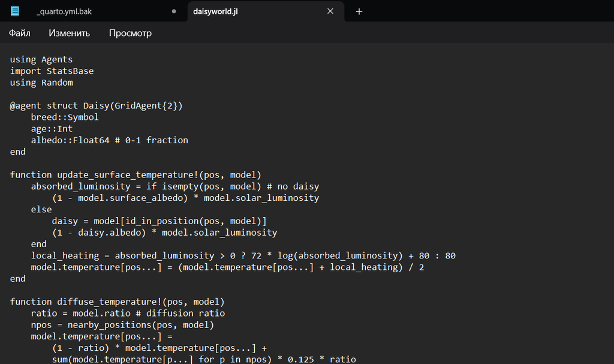

Рисунок 1: src/daisyworld.jl

## Базовая визуализация

Сделаем базовую визуализацию. Построим тепловую карту, которая будет представлять собой температуру поверхности модели. Маргаритки будут отображаться черно-белыми в соответствии с их видом (рис. 2).

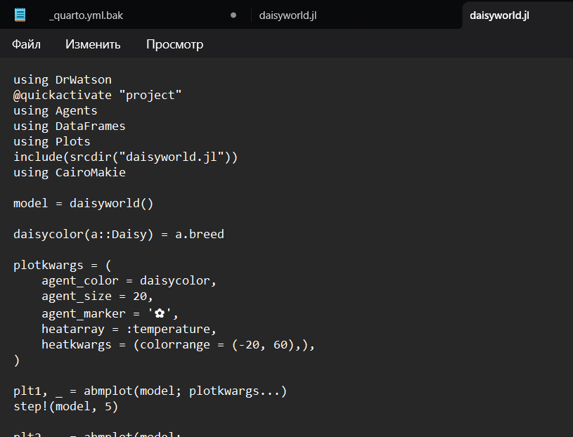

Рисунок 2: scripts/daisyworld.jl

## Базовая визуализация

Запустим скрипт (рис. 3).

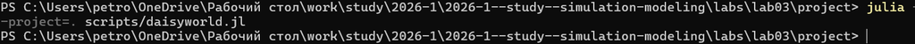

Рисунок 3: scripts/daisyworld.jl

## Базовая визуализация

Просмотрим результирующие изображения в каталоге plots (рис. 4):

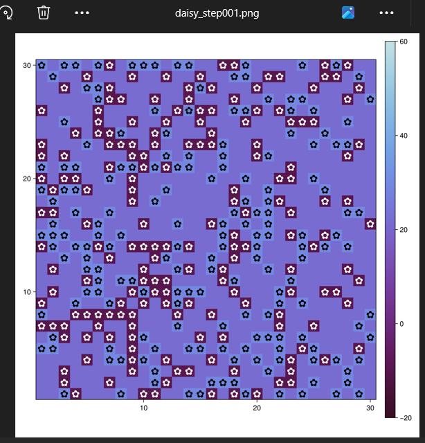

Рисунок 4: daisy_step001

## Базовая визуализация

(рис. 5):

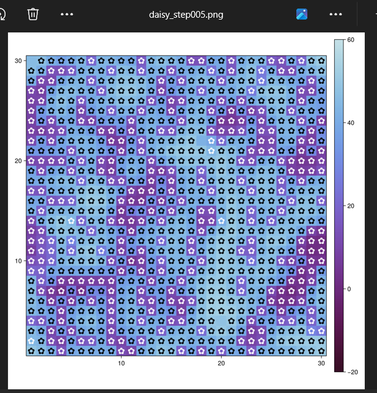

Рисунок 5: daisy_step005

## Базовая визуализация

(рис. 6):

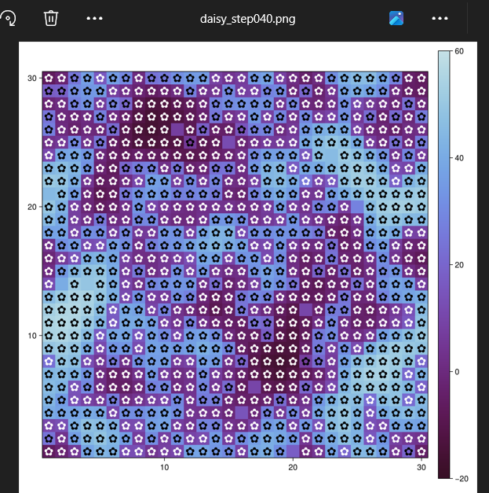

Рисунок 6: daisy_step040

## Базовая визуализация

Создадим производные форматы с помощью скрипта tangle.jl (рис. 7).

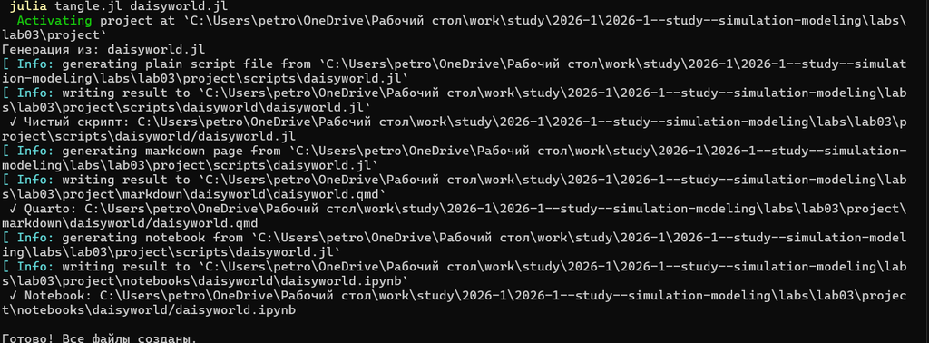

Рисунок 7: Создание производных форматов

## Базовая визуализация

Запустим файл ipynb в jupyter-notebook (рис. 8).

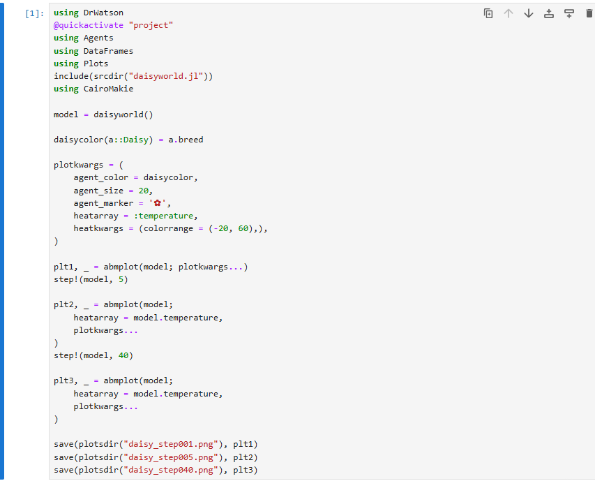

Рисунок 8: Запуск файла в jupyter-notebook

## Анимация модели

Создадим визуализацию не отдельных моментов, а видео эволюции модели (рис. 9).

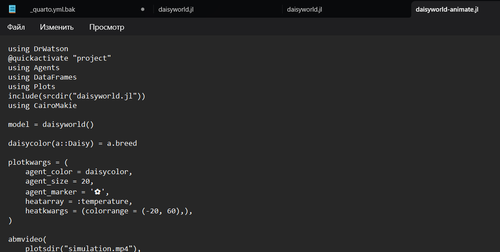

Рисунок 9: scripts/daisyworld-animate.jl

## Анимация модели

Запустим скрипт (рис. 10).

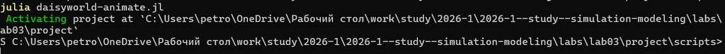

Рисунок 10: scripts/daisyworld-animate.jl

## Анимация модели

Просмотрим результирующую анимацию в каталоге plots (рис. 11)

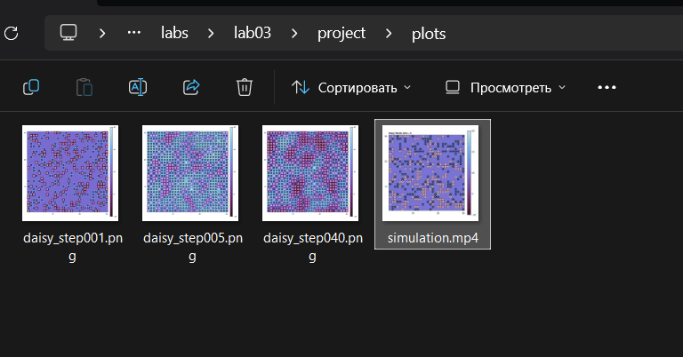

Рисунок 11: daisyworld-animate.jl

## Анимация модели

Видео можно посмотреть здесь:

[simulation.mp4](https://rutube.ru/video/private/ee51c2167ac27466bc8735fdcec98ea5/?p=nqFT3WUNjNtEbWLaoc50UA) [simulation.mp4](https://vkvideo.ru/clip-236836260_456239018)

## Динамика числа маргариток

Построим график изменения числа маргариток в зависимости от модельного времени (рис. 12).

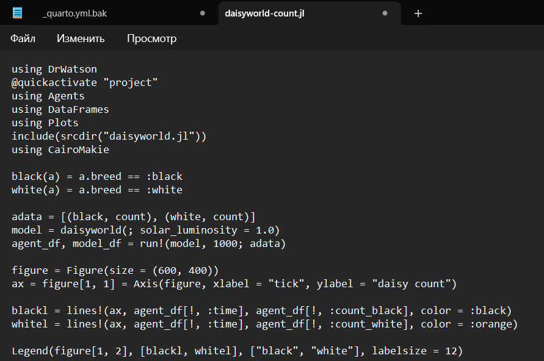

Рисунок 12: scripts/daisyworld-count.jl

## Динамика числа маргариток

Запустим скрипт (рис. 13).

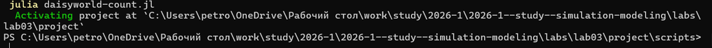

Рисунок 13: scripts/daisyworld-count.jl

## Динамика числа маргариток

Создадим производные форматы с помощью скрипта tangle.jl (рис. 14).

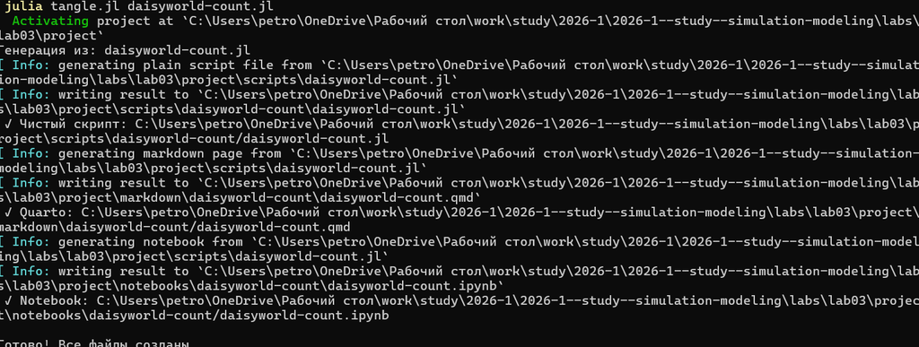

Рисунок 14: Создание производных форматов

## Динамика числа маргариток

Запустим файл ipynb в jupyter-notebook (рис. 15).

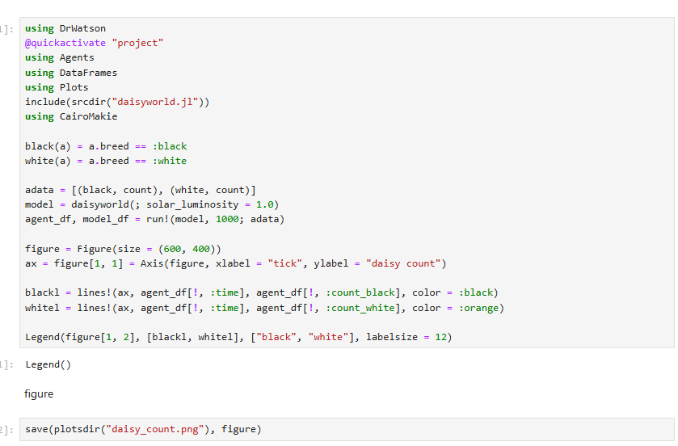

Рисунок 15: Запуск файла в jupyter-notebook

## Динамика числа маргариток

Просмотрим результирующие изображения в каталоге plots (рис. 16):

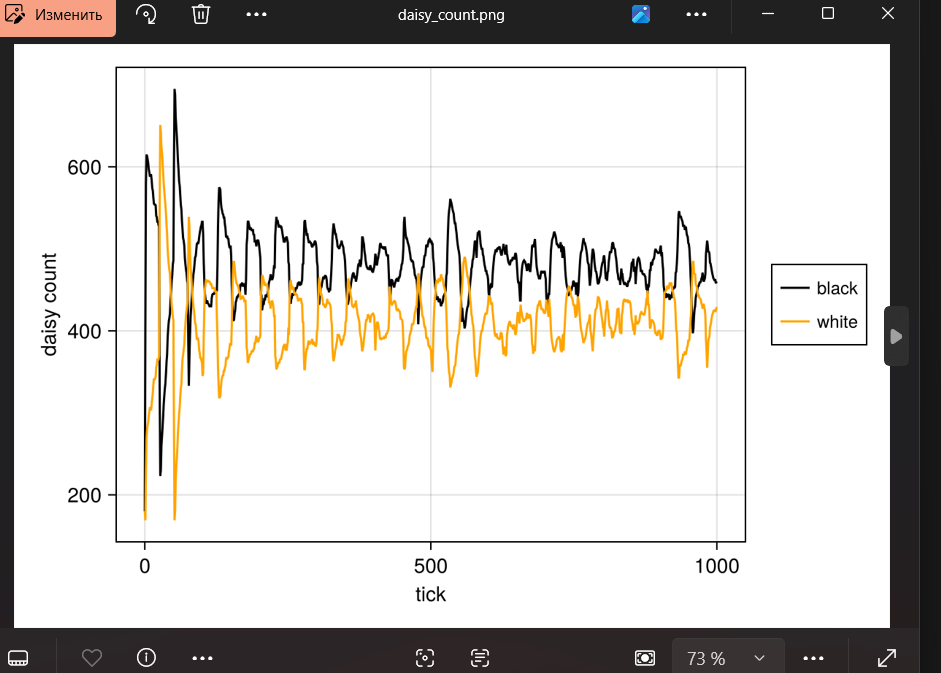

Рисунок 16: daisy_count

## Динамика модели

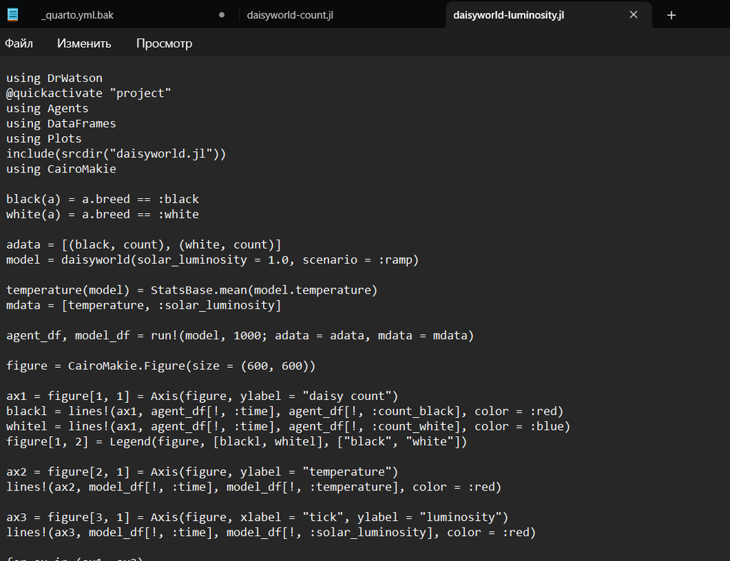

Рисунок 17: scripts/daisyworld-luminosity.jl

## Динамика модели

Запустим скрипт (рис. 18).

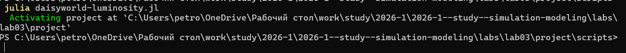

Рисунок 18: scripts/daisyworld-luminosity.jl

## Динамика модели

Создадим производные форматы с помощью скрипта tangle.jl (рис. 19).

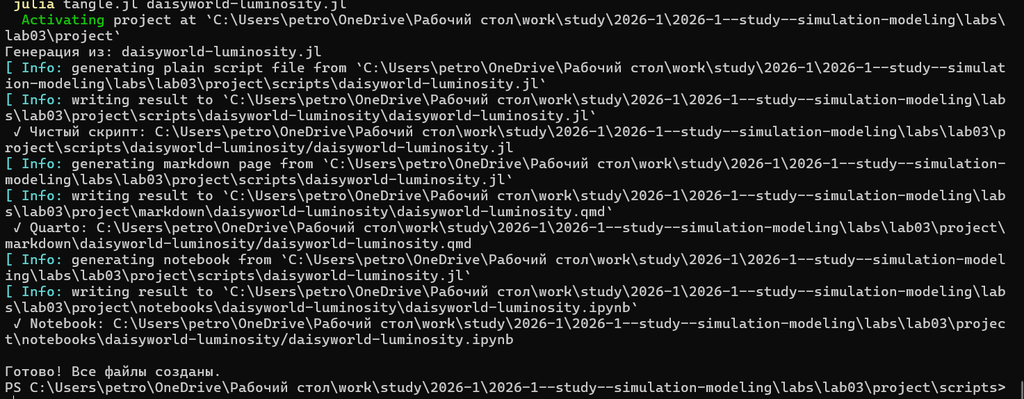

Рисунок 19: Создание производных форматов

## Динамика модели

Запустим файл ipynb в jupyter-notebook (рис. 20).

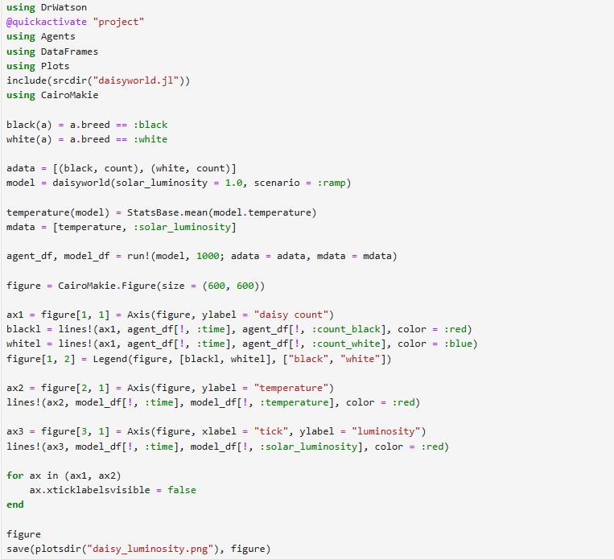

Рисунок 20: Запуск файла в jupyter-notebook

## Динамика модели

Просмотрим результирующие изображения в каталоге plots (рис. 21):

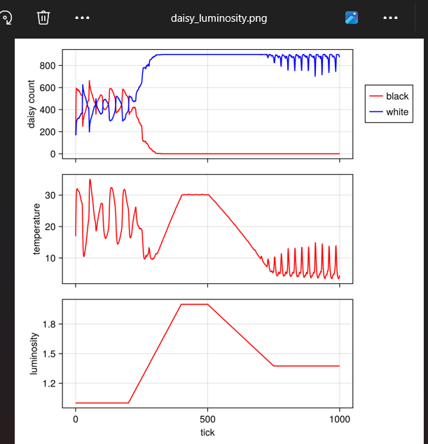

Рисунок 21: daisy_luminosity

## Базовая визуализация (параметры)

Расширим базовую визуализацию за счёт параметров (рис. 22).

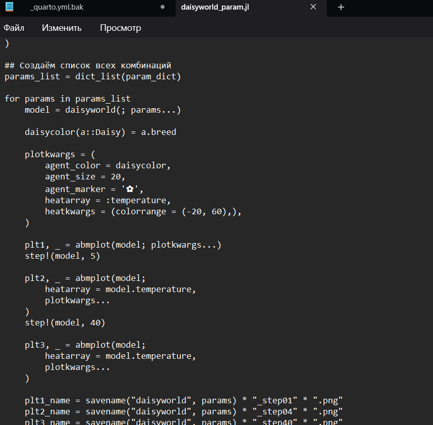

Рисунок 22: scripts/daisyworld__param.jl

## Базовая визуализация (параметры)

Запустим скрипт (рис. 23).

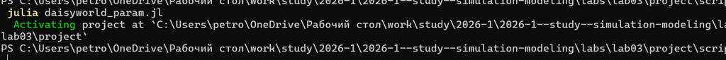

Рисунок 23: scripts/daisyworld__param.jl

## Базовая визуализация (параметры)

Просмотрим результирующие изображения в каталоге plots (рис. 24).

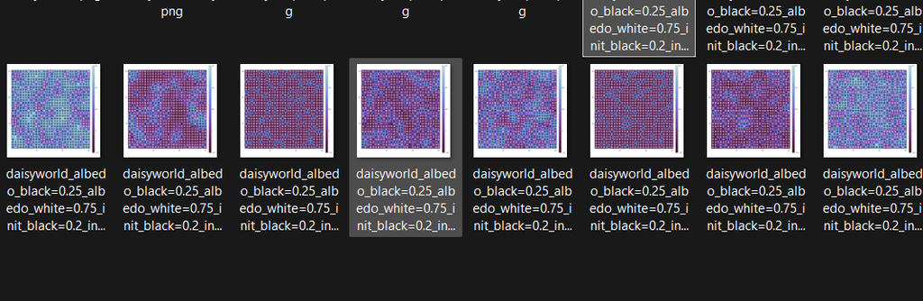

Рисунок 24: daisyworld__params

## Базовая визуализация (параметры)

Создадим производные форматы с помощью скрипта tangle.jl (рис. 25).

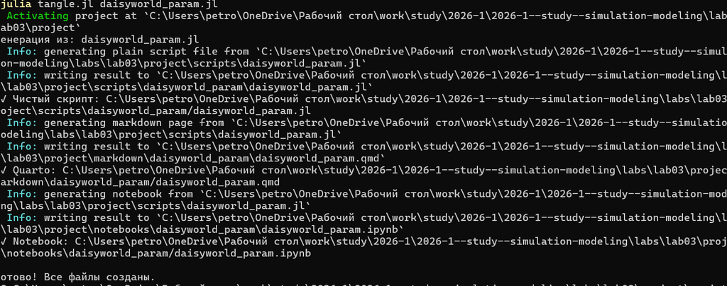

Рисунок 25: Создание производных форматов

## Базовая визуализация (параметры)

Запустим файл ipynb в jupyter-notebook (рис. 26).

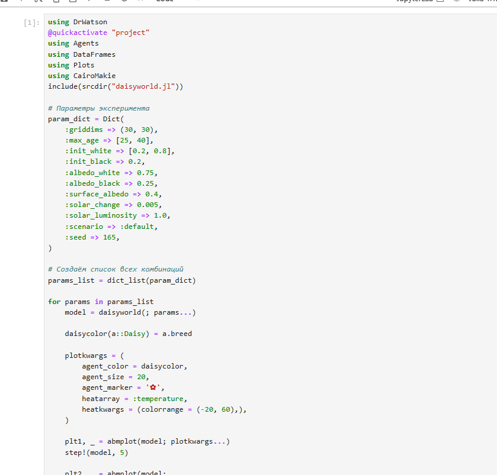

Рисунок 26: Запуск файла в jupyter-notebook

## Динамика числа маргариток (параметры)

Построим график изменения числа маргариток в зависимости от модельного времени с разными параметрами модели (рис. 27).

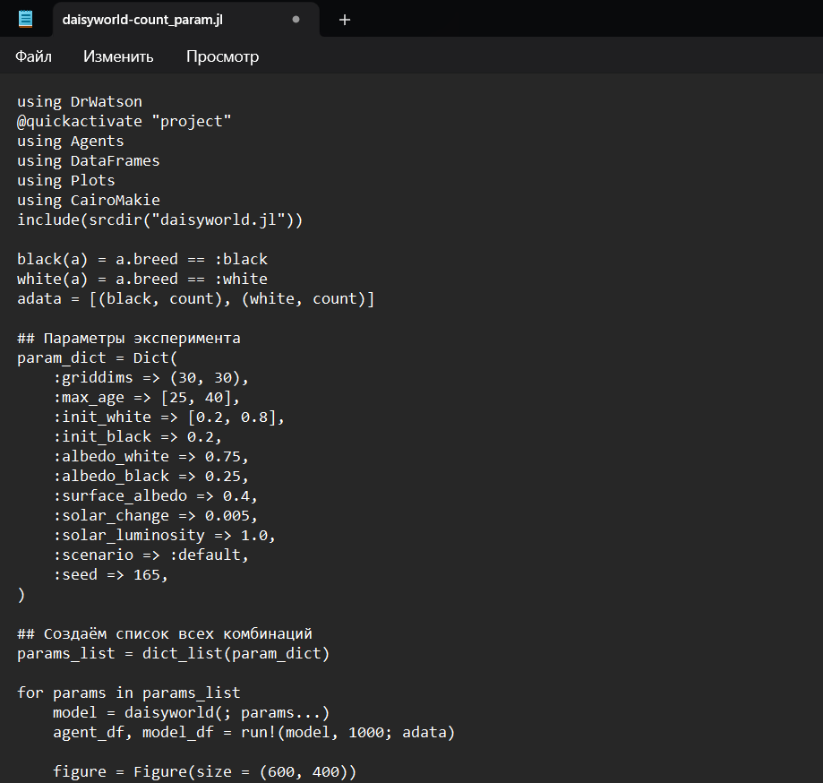

Рисунок 27: scripts/daisyworld-count__param.jl

## Динамика числа маргариток (параметры)

Запустим скрипт (рис. 28).

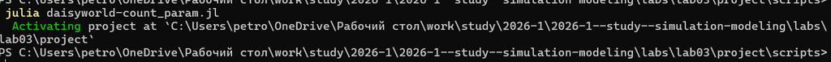

Рисунок 28: scripts/daisyworld-count__param.jl

## Динамика числа маргариток (параметры)

Просмотрим результирующие изображения в каталоге plots (рис. 29).

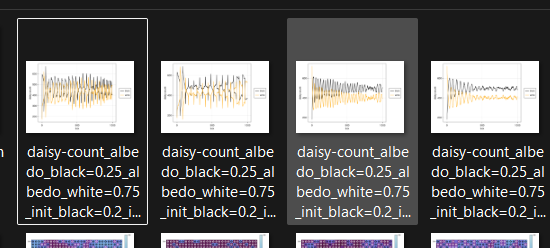

Рисунок 29: daisyworld-count__params

## Динамика числа маргариток (параметры)

Создадим производные форматы с помощью скрипта tangle.jl (рис. 30).

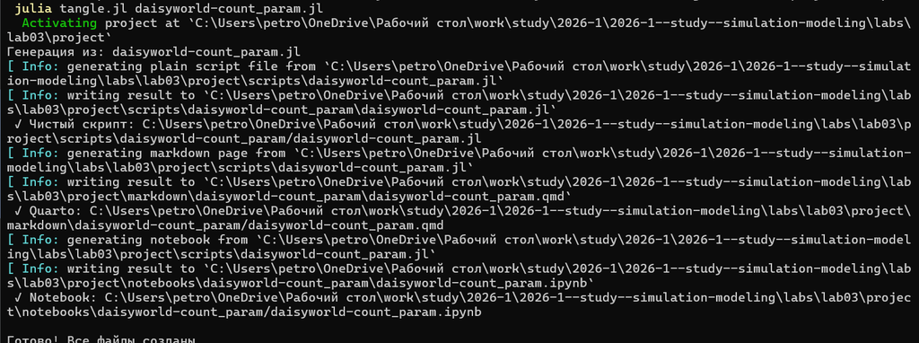

Рисунок 30: Создание производных форматов

Запустим файл ipynb в jupyter-notebook (рис. 31).

## Динамика числа маргариток (параметры)

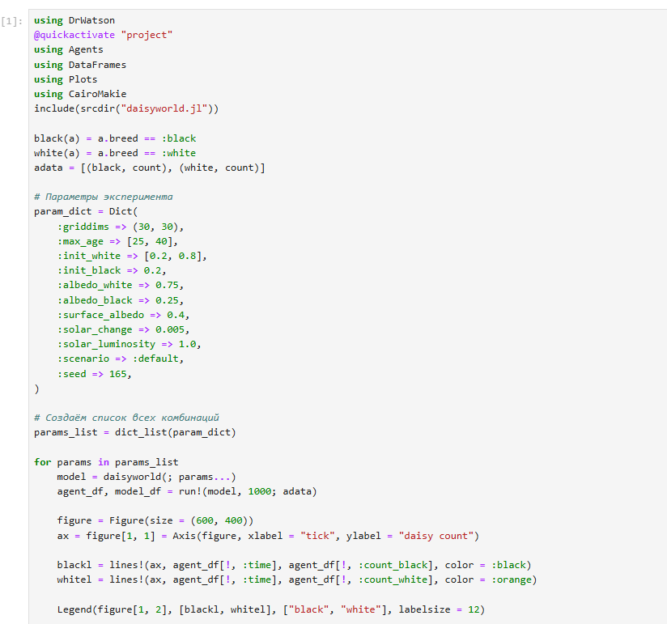

Рисунок 31: Запуск файла в jupyter-notebook

## Динамика модели (параметры)

Построим график изменения числа маргариток в зависимости от модельного времени с разными параметрами модели (рис. 32).

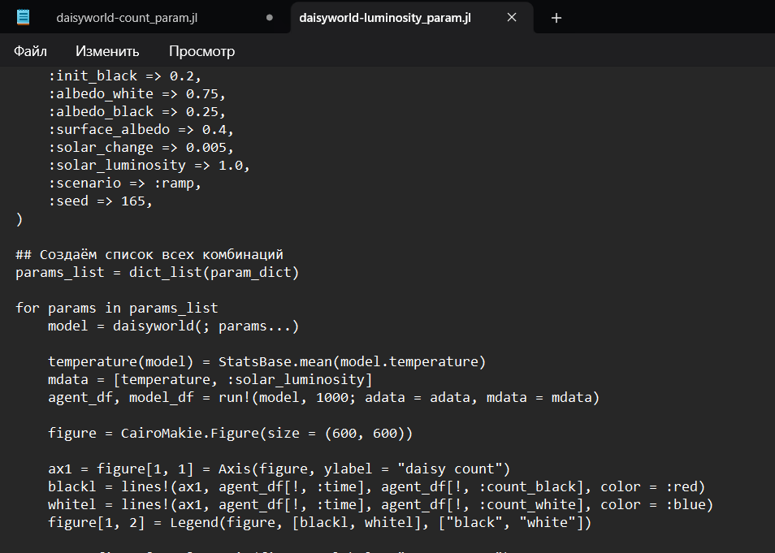

Рисунок 32: scripts/daisyworld-luminosity__param.jl